# Bank Churn Prediction

## Description

### Background and Context

Businesses like banks that provide service have to worry about the problem of 'Churn' i.e. customers leaving and joining another service provider. It is important to understand which aspects of the service influence a customer's decision in this regard. Management can concentrate efforts on the improvement of service, keeping in mind these priorities.

## Objective

Given a Bank customer, build a neural network-based classifier that can determine whether they will leave or not in the next 6 months.

## Data Description

The case study is from an open-source dataset from Kaggle. The dataset contains 10,000 sample points with 14 distinct features such as CustomerId, CreditScore, Geography, Gender, Age, Tenure, Balance, etc.

## Data Dictionary

- **CustomerId:** Unique ID which is assigned to each customer
- **Surname:** Last name of the customer
- **CreditScore:** It defines the credit history of the customer.
- **Geography:** A customer’s location
- **Gender:** It defines the Gender of the customer
- **Age:** Age of the customer
- **Tenure:** Number of years for which the customer has been with the bank
- **NumOfProducts:** It refers to the number of products that a customer has purchased through the bank.
- **Balance:** Account balance
- **HasCrCard:** It is a categorical variable that decides whether the customer has a credit card or not.
- **EstimatedSalary:** Estimated salary
- **isActiveMember:** It is a categorical variable that decides whether the customer is an active member of the bank or not ( Active member in the sense, using bank products regularly, making transactions, etc )
- **Excited:** It is a categorical variable that decides whether the customer left the bank within six months or not. It can take two values
  - 0=No ( Customer did not leave the bank )
  - 1=Yes ( Customer left the bank )

```python
from google.colab import drive
drive.mount('/content/drive')
```

```python
import numpy as np
import pandas as pd
import matplotlib.pyplot as plt
import seaborn as sns
sns.set()
from matplotlib import pyplot
from scipy import stats
from sklearn.model_selection import train_test_split
from sklearn import preprocessing
from sklearn.preprocessing import StandardScaler
from sklearn.metrics import explained_variance_score, mean_squared_error, r2_score, mean_absolute_error
from collections import Counter
from keras import callbacks
import tensorflow as tf
from tensorflow.keras.layers import Dense, Dropout,InputLayer
from tensorflow.keras.models import Sequential
from keras.layers import BatchNormalization
from tensorflow.keras import regularizers
from tensorflow.keras import backend
from random import shuffle
from keras.callbacks import ModelCheckpoint
from tensorflow.keras.optimizers import Adam
from tensorflow.keras.optimizers import RMSprop
import keras
import sys
from keras.models import Sequential
from keras.layers import Dense
import warnings
warnings.filterwarnings("ignore")
```

## Reading the Dataset

```python
#Since data is in form of excel file we have to use pandas pd.read_excel to load the data.
data = pd.read_csv('/content/drive/MyDrive/Churn.csv')
```

## Print the first five rows of the data

```python
data.head()
```

|  | RowNumber | CustomerId | Surname | CreditScore | Geography | Gender | Age | Tenure | Balance | NumOfProducts | HasCrCard | IsActiveMember | EstimatedSalary | Exited |
| --- | --- | --- | --- | --- | --- | --- | --- | --- | --- | --- | --- | --- | --- | --- |
| 0 | 1 | 15634602 | Hargrave | 619 | France | Female | 42 | 2 | 0.00 | 1 | 1 | 1 | 101348.88 | 1 |
| 1 | 2 | 15647311 | Hill | 608 | Spain | Female | 41 | 1 | 83807.86 | 1 | 0 | 1 | 112542.58 | 0 |
| 2 | 3 | 15619304 | Onio | 502 | France | Female | 42 | 8 | 159660.80 | 3 | 1 | 0 | 113931.57 | 1 |
| 3 | 4 | 15701354 | Boni | 699 | France | Female | 39 | 1 | 0.00 | 2 | 0 | 0 | 93826.63 | 0 |
| 4 | 5 | 15737888 | Mitchell | 850 | Spain | Female | 43 | 2 | 125510.82 | 1 | 1 | 1 | 79084.10 | 0 |

```python
#Information about the data
data.info()
```

```
<class 'pandas.core.frame.DataFrame'>
RangeIndex: 10000 entries, 0 to 9999
Data columns (total 14 columns):
 #   Column           Non-Null Count  Dtype
---  ------           --------------  -----
 0   RowNumber        10000 non-null  int64
 1   CustomerId       10000 non-null  int64
 2   Surname          10000 non-null  object
 3   CreditScore      10000 non-null  int64
 4   Geography        10000 non-null  object
 5   Gender           10000 non-null  object
 6   Age              10000 non-null  int64
 7   Tenure           10000 non-null  int64
 8   Balance          10000 non-null  float64
 9   NumOfProducts    10000 non-null  int64
 10  HasCrCard        10000 non-null  int64
 11  IsActiveMember   10000 non-null  int64
 12  EstimatedSalary  10000 non-null  float64
 13  Exited           10000 non-null  int64
dtypes: float64(2), int64(9), object(3)
memory usage: 1.1+ MB
```

```python
#Checking the shape of the data
data.shape
```

```
(10000, 14)
```

```python
#finding the null values
data.isnull().sum()
```

```
RowNumber          0
CustomerId         0
Surname            0
CreditScore        0
Geography          0
Gender             0
Age                0
Tenure             0
Balance            0
NumOfProducts      0
HasCrCard          0
IsActiveMember     0
EstimatedSalary    0
Exited             0
dtype: int64
```

```python
#Checking the dtypes of the variables in the data
data.dtypes
```

```
RowNumber            int64
CustomerId           int64
Surname             object
CreditScore          int64
Geography           object
Gender              object
Age                  int64
Tenure               int64
Balance            float64
NumOfProducts        int64
HasCrCard            int64
IsActiveMember       int64
EstimatedSalary    float64
Exited               int64
dtype: object
```

```python
#Checking the unique values in the data
data.nunique()
```

```
RowNumber          10000
CustomerId         10000
Surname             2932
CreditScore          460
Geography              3
Gender                 2
Age                   70
Tenure                11
Balance             6382
NumOfProducts          4
HasCrCard              2
IsActiveMember         2
EstimatedSalary     9999
Exited                 2
dtype: int64
```

```python
# Drop the columns RowNumber , CustomerID and SurName since we have default serial numbers and it doesn't make any difference in the prediction
#data = data.drop(["RowNumber", "CustomerId", "Surname"], axis = 1)
```

```python
# Review the top rows of what is left of the data frame
data.head()
```

[output not shown]

## Exploratory Data Analysis

### Univariate Analysis

```python
# function to create labeled barplots


def labeled_barplot(data, feature, perc=False, n=None):
    """
    Barplot with percentage at the top

    data: dataframe
    feature: dataframe column
    perc: whether to display percentages instead of count (default is False)
    n: displays the top n category levels (default is None, i.e., display all levels)
    """

    total = len(data[feature])  # length of the column
    count = data[feature].nunique()
    if n is None:
        plt.figure(figsize=(count + 1, 5))
    else:
        plt.figure(figsize=(n + 1, 5))

    plt.xticks(rotation=90, fontsize=15)
    ax = sns.countplot(
        data=data,
        x=feature,
        palette="Paired",
        order=data[feature].value_counts().index[:n].sort_values(),
    )

    for p in ax.patches:
        if perc == True:
            label = "{:.1f}%".format(
                100 * p.get_height() / total
            )  # percentage of each class of the category
        else:
            label = p.get_height()  # count of each level of the category

        x = p.get_x() + p.get_width() / 2  # width of the plot
        y = p.get_height()  # height of the plot

        ax.annotate(
            label,
            (x, y),
            ha="center",
            va="center",
            size=12,
            xytext=(0, 5),
            textcoords="offset points",
        )  # annotate the percentage

    plt.show()  # show the plot
```

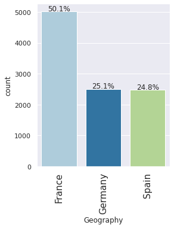

```python
labeled_barplot(data, "Geography", perc=True)
```

**Observations:**

- Most of the data is from France(50.1%).
- Comparatively lowest is Spain(24.8%).

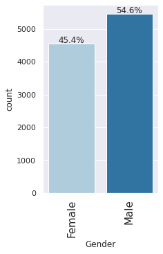

```python
labeled_barplot(data, "Gender", perc=True)
```

**Observations:**

- Most of the customers are male(54.6%) in the dataset.

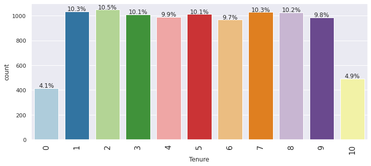

```python
labeled_barplot(data, "Tenure", perc=True)
```

**Observations:**

- Looks like almost 1 year to 9 years of tenure customers are almost equal but more than 10 years of tenure customers and less than 1 year customers are very less.

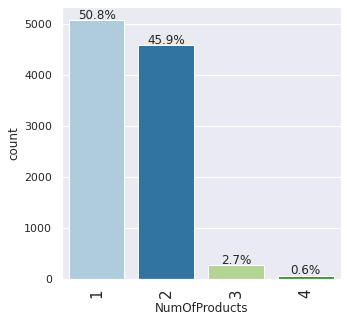

```python
labeled_barplot(data, "NumOfProducts", perc=True)
```

**Observations:**

- Most of the customers(50.8%) purchased 1 product through bank and second highest(45.9%) is 2 products.

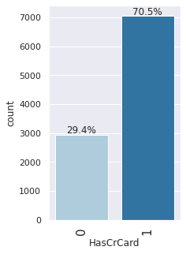

```python
labeled_barplot(data, "HasCrCard", perc=True)
```

**Observations:**

- 70.5% of the customers has credit card.

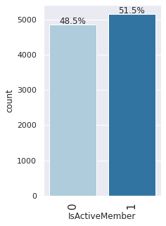

```python
labeled_barplot(data, "IsActiveMember", perc=True)
```

**Observations:**

- Active customers(51.5%) are higher than non active customers(48.5%)

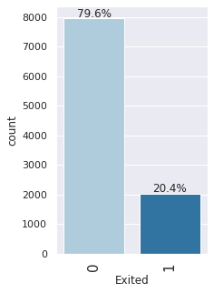

```python
labeled_barplot(data, "Exited", perc=True)
```

**Observations:**

- 79.6% of the customers didn't leave the bank.
- 20.4% of the customers left the bank.

## Bivariate analysis

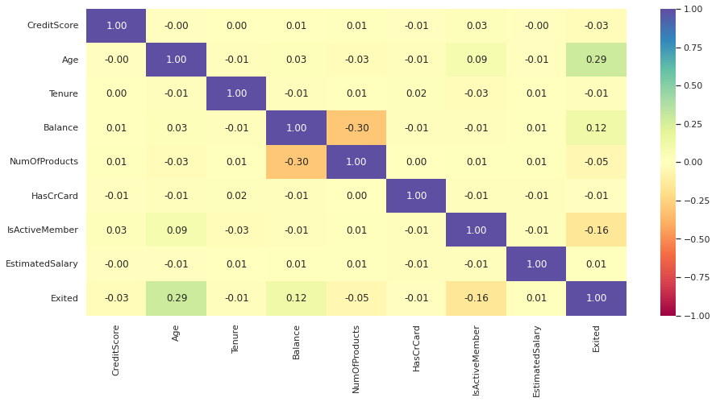

```python
plt.figure(figsize=(15, 7))
sns.heatmap(
    data.corr(), annot=True, vmin=-1, vmax=1, fmt=".2f", cmap="Spectral"
)
plt.show()
```

**Observations:**

### Geography vs Exited

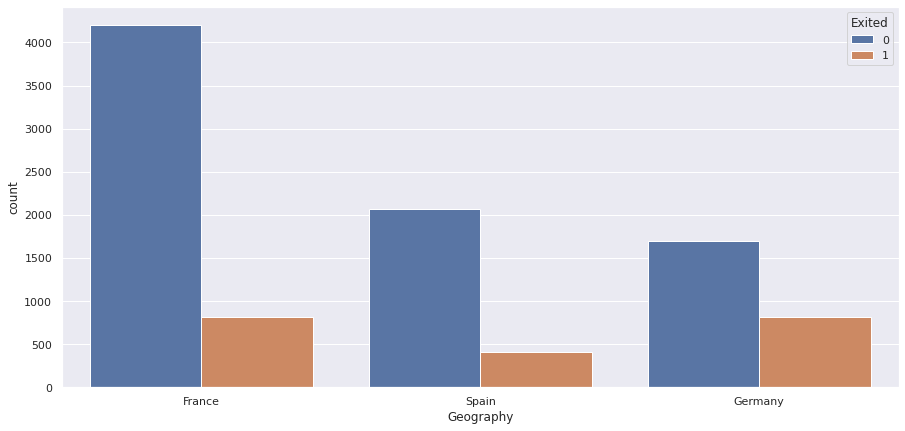

```python
plt.figure(figsize=(15,7))
sns.countplot(x='Geography',hue='Exited', data=data);
```

**Observations:**

### Gender vs Exited

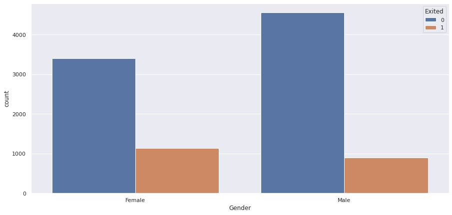

```python
plt.figure(figsize=(15,7))
sns.countplot(x='Gender',hue='Exited', data=data);
```

**Observations:**

- Female customers are churning greater than male customers.

### HasCrCard vs Exited

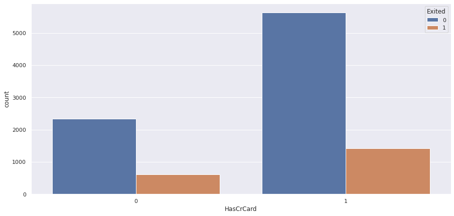

```python
plt.figure(figsize=(15,7))
sns.countplot(x='HasCrCard',hue='Exited', data=data);
```

**Observations:**

- Majority of the customers that churned are those with credit cards.

### IsActiveMember vs Exited

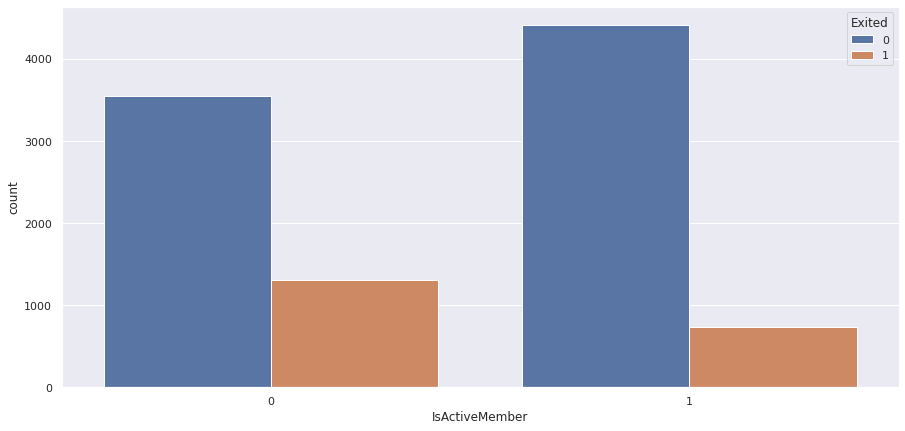

```python
plt.figure(figsize=(15,7))
sns.countplot(x='IsActiveMember',hue='Exited', data=data);
```

**Observations:**

### Tenure vs Exited

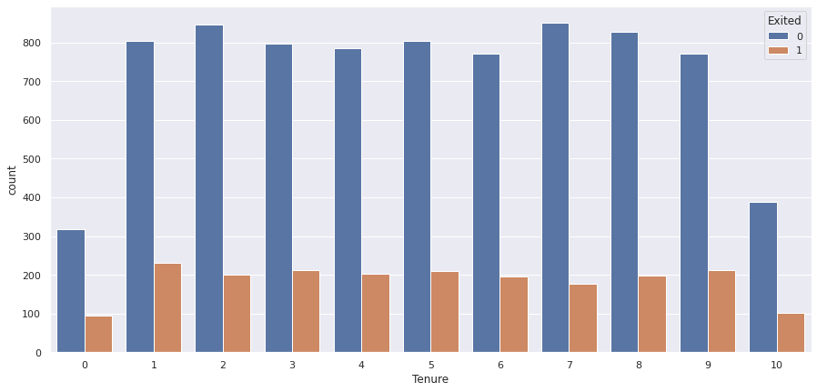

```python
plt.figure(figsize=(15,7))
sns.countplot(x='Tenure',hue='Exited', data=data);
```

**Observations:**

### NumOfProducts vs Exited

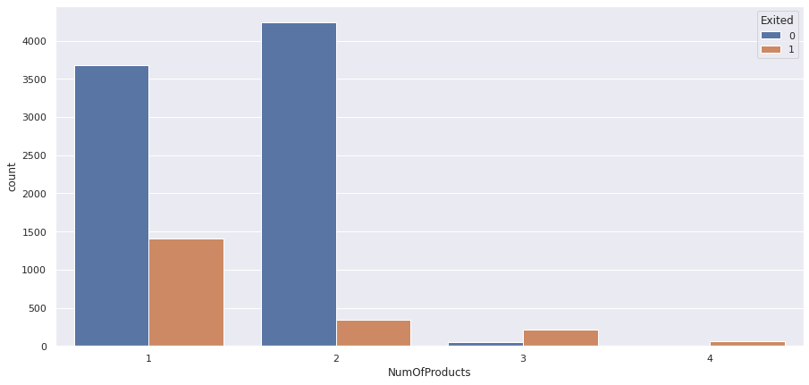

```python
plt.figure(figsize=(15,7))
sns.countplot(x='NumOfProducts',hue='Exited', data=data);
```

**Observations:**